# Errabundio

# Prolegómeno

**I**

«Abundio Martín Gala apagó el despertador antes de que sonara y se calzó las babuchas sin despertar al gato y, menos, a Paquita. Como el calendario rondaba su solsticio más alegre, pudo encontrar la bolsita de té mercatrona y tostar el pan sin encender la luz de la cocina. Después del pitufo con aceite se puso la corbata macerada por salpicones históricos, la chaqueta de pana que en sus tiempos debía de haber sido marrón, o gris tal vez, y cerró la puerta con dos vueltas de cerradura.

Abundio Martín Gala era un hombre de costumbres tan férreas como ortogonales, lo cual no era inconveniente ni ventaja. Por ejemplo, si cruzara las calles como todos sus imprudentes conciudadanos, podría acortar su caminata en un factor $\sqrt{2}$ pero a él le daba igual porque, como no dependía de transporte público ni vehículo propio, su puntualidad era más afilada que el lápiz que llevaba en la oreja. A las 7:53, como todos los laborables desde hacía cuarenta años, cruzó el último paso de peatones y llegó a su destino. El abyecto cartel pegado a la puerta de cristal rezaba `SE ALQUILA` en letras rojas sobre fondo amarillo. El vacío que sentía en la boca del estómago no desaparecía, por más tiempo que hubiera pasado desde que lo jubilaron.

Abundio Martín Gala no era especialmente listo ni tonto, espabilado ni torpe, trabajador ni vago. Había sido justo lo suficiente de todo eso como para encontrar trabajo de joven en el Banco Hispano Lusitano gracias a su espantosa capacidad para el cálculo mental. Cuando chico, dejaba perplejos a sus compañeros de pupitre al resolver de golpe las perversas multiplicaciones de seis pisos con las que don Carlos, su maestro, los castigaba por lanzar pelotillas de papel masticado con el canuto del boli, intentando ponerle los puntos a las íes de la pizarra, o meterlas por la oreja del Zambrano, el pelota de la clase. Sumas, restas, multiplicaciones, divisiones, con decimales a porrillo, ocuparan el ancho de la libreta o no, caían instantáneamente bajo su afilado lápiz, que inocentemente exhibía las tablas de multiplicar impresas en el lomo. Eso sí, ahí paraba su habilidad; las raíces cuadradas, polinomios y demás zarandajas matemáticas se le atravesaban igual que a sus compañeros. Su prodigio era puramente lineal.

Abundio Martín Gala se quedó en el paro cuando la Confederación Oriental de Cajas de Ahorro (nombre que tomó el Hispano Lusitano después de la primera reconversión económica del País de las Albóndigas) fue absorbida por el poderoso Banco Internacional. La nueva entidad bancaria, el B.I.C.O.C.A., jubiló desincentivadamente a todos los empleados mayores de 45 años y despidió con cajas destempladas a los menores de 46, mientras que los directivos salieron de la cárcel antes de entrar, en una pirueta financiero-judicial que quedó como paradigma en los *Pelotazing and Economical Onerose Strategies*, tratado que desde hacía lustros desplazó al Keynes como manual de cabecera en el *Ministerio de Asuntos Monetarios Obtusos y Nueva Economía Onanista*. Algunos pensadores (perseguidos, por supuesto) sostenían que tales artimañas no obedecían las leyes de la física conocida, opinión más que equivocada, tal como se enseñaba en la Nueva Enciclopedia Álvarez Bilingüe, compendio de todo el saber necesario para la plebe, publicada en Toledo por el *Ministerio de Educación Anestésica, Pluridiversidad Interdisciplinar y Latrocinio Académico Sostenible*, que se repartía en los colegios en suaves supositorios de conocimiento (las píldoras se eliminaron por contener gluten).

Abundio Martín Gala aún no le había contado a Paquita el asunto y el pobre se dedicaba a deambular linealmente por las calles hasta la hora de comer. Llevaba así doce años. Aquel día, sin embargo, fue providencial. Cuando iba a cruzar por frente la *Peña el Jubileta Bacileta* (a la que llevaba diez años resistiéndose) se topó con un cateto que llevaba un manojo espárragos.

—Perdone, amigo, que casi me salta un ojo con esas varas verdes.

—Ustéperdone —dijo el cateto—. ¿Me compra un manojo?

—Uhmm, no creo que lo necesite, gracias. ¿Qué son?

—¿Como que quesón? ¡¡Pos espárragos, qué vanasé!! —exclamó el cateto—. Esto lo fríe usté y le sale una tortillica mu güena.

—Bueno, deme usted uno —dijo después de un rato que el cateto le sostuvo con mirada impertérrita—. Hoy es nuestro aniversario y nunca le he llevado un regalo a Paquita.

—Ya verá usté que contenta se pone —dijo el cateto trincando los veinte sestercios antes de soltar el manojo.

Abundio Martín Gala tuvo el aniversario más feliz que pudo recordar. A Paquita se le saltaron las lágrimas, no se sabe si por el regalo, o la emoción de haber visto a su marido por primera vez en la cocina, o por lo duros que estaban los dichosos espárragos. Envalentonado y sin duda fustigado por una nueva motivación, al día siguiente se echó a la calle en busca del cateto. Su vida había cambiado.

Abundio Martín Gala, por primera vez en medio siglo, no fue a su trabajo.

**II**

Llevaba casi tres horas apostado en la esquina del *Jubileta Bacileta* sin que apareciera el cateto de marras. Finalmente, se atrevió a entrar en la peña y dirigirse a sus parroquianos. Así empezó su viaje iniciático.

—Perdonen ustedes —empezó a decir cortésmente a los cuatro usuarios de la mesa más cercana a la puerta, cuando uno de ellos hizo un estentóreo alzamiento de brazo y gritó explosivamente, bajándolo con la misma fuerza que cae un árbol talado.

—¡¡Me doblo!! —vociferó mientras intentaba incrustar, al parecer, una pieza rectangular blanca y negra en la mesa, haciendo saltar todas la que allí yacían colocadas en un enigmático y zigzagueante camino enlosado.

—Perdonen —insistió, recuperándose del repullo e, instintivamente, intentando comprender alguna regla de aquel extraño juego.

—¿Ein? —dijo el del lado sur, mientras lo miraba guiñando un ojo hacia arriba y torciendo la boca en claro indicio de indagación sobre el nuevo visitante.

La partida se detuvo y Abundio pudo interpelar adecuadamente a los curtidos jugadores.

—¿Cuando viene el vendedor de espárragos? —preguntó solícito.

—¿Ein? —volvió a decir el mismo de antes, dueño de una ciclópea cabeza tan frondosamente cubierta de canas que no dejaba resquicio al cartón.

—¿El Ozeíllo? —dijo el del oeste—. Ese no viene los martes.

—Pero hoy es jueves —repuso Abundio.

—Pos tampoco ha venío —intervino el jugador del norte, sin levantar las gafas de sus fichas—, el Ozeíllo es mu informal.

—¡Informal dice! El íopuchi toavía no ha pagao el mes —explicó el cíclope canoso, tapando desconfiado las otras fichas que tenía delante del regazo.

—¿Creen que vendrá más tarde?

—A lo meón sí —dijo sin mucha convicción el del este, que aún tenía la palma de la mano colorá desde la última jugada—. Pero es un tío mu informal, no se fíusté.

—¡¡A cincos!! —y pegaron otro leñazo en la mesa, dejando de lado al compungido Abundio.

**III**

Lo poco que pudo averiguar es que el Ozeíllo vivía en *las afueras*, venía de vez en cuando (nunca los martes) y debía el mes. No obstante, Abundio era impulsado ahora por una extraordinaria motivación que no recordaba haber sentido desde que tenía quince años.

—¡Iré a *las afueras*!

[figure not shown]

**Figura 1. El plano de autobuses que Abundio pudo consultar en la parada de la peña.** Según el mapa, *la Virreina* quedaba de su casa más o menos a la misma distancia que el *Jubileta Bacileta*, así que podría ir andando.

Lo más lejos que conocía Abundio hacia el norte era su antiguo colegio, en el que de chico le contaban leyendas sobre las lejanas tierras allende *la Virreina*, una finca abandonada en plena frontera de la ciudad, a la que nunca se atrevió a ir de excursión con sus intrépidos compañeros. Pero ahora era distinto, estaba dispuesto a todo y, según el mapa, *las afueras* distaban de su casa, aproximadamente, lo mismo que la peña y, más o menos, el doble que su colegio.

Memorizó el plano autobusero y mentalmente fue trazando la trayectoria que sus pies recorrían, con ortogonalidad euclídea y escrupuloso respeto viario, hacia *las afueras*. Un cosquilleo jamás sentido le recorría el espinazo cada vez que pensaba en esas palabras: *las afueras, las afueras…*

**IV**

Según sus cálculos, ya debería haber llegado a *la Virreina* pero aún seguía andando en la dirección del último ramal rojo del mapa.

—Me he perdido —pensó con un atisbo de miedo mientras miraba alrededor, en aquella remota zona desconocida que jamás había imaginado que podría pisar algún día, ni siquiera en sus momentos juveniles más temerarios. Las casas eran bajas y estaban separadas de la calzada central por unos jardines jalonados regularmente con naranjos muy robustos. No se veía a nadie por la calle y tampoco veía el final de la carretera, que se desvanecía en una inquietante bruma. Recordó las aventuras narradas por el Juanjosé y el Rafa, sus insensatos compañeros de colegio, y empezó a aterrorizarse. El olor del azahar lo calmó un poco, manteniéndolo atado a la realidad.

En eso, que llegaba el autobús número 15 (alias *el Citesa*, que hacía la ruta roja) y abrió sus puertas con un mecánico chiflido. Abundio se quedó mirando al conductor a través del dintel plegable.

—Señor conductor —preguntó con su habitual cortesía—. ¿Esta es la ruta hacia *la Virreina*?

—Sí —respondió lacónica y abrutamente el conductor, sin mirar siquiera hacia la puerta.

—Es que… —comenzó a decir dubitativamente Abundio— …me parece que el plano está mal. Esta parada está mucho más lejos que lo indicado por su representación en el mapa.

—¿Cómo? —dijo el conductor, mirando por primera vez la apacible silueta de Abundio.

—Que creo que esta parada está mal representada en el plano porque la distancia real es mucho mayor que la proporcional según la escala del mapa —respondió humildemente, dándole más detalles al probo empleado consistorial.

—¿Va a subirse o solo quiere tocarme los coones? —le espetó agriamente el conductor, haciendo amago de cerrar la puerta.

Ante tal disyuntiva, decidió subirse para abreviar el camino hasta la última parada, en el supuesto de que existiera. Como no recordaba la última vez que usó el autobús, tuvo que soportar de nuevo las irascibles sentencias del conductor antes de aflojar los dos sestercios que costaba el billete.

**V**

El *Citesa* bufó neumáticamente cuando se marchó dejando abandonado a Abundio en una rotonda desamparada, que parecía solo destinada al cambio de sentido del autobús. Vio como el autobús desaparecía a través de la bruma de vuelta en su ruta infinita, plegada sobre sí misma hasta el hastío, y casi pudo comprender las estoicas maneras de los timoneles municipales.

Para su sorpresa, no tenía el más mínimo temor a pesar de la soledad de aquellos parajes. Aquella rotonda era, en efecto, uno de los extremos de la ciudad de la que nunca había salido. Un bordillo de granito grisáceo trazaba la circunferencia exterior de la rotonda con una pulcritud digna del mejor alarife nazarí. Más allá de tan conspicua frontera solo se veía un manto heterogéneo de color verde brillante indefinido, salpicado por puntos de intensos colores y manchas ocres difuminadas entre azules oscuros proyectados por unos árboles corpulentos, completamente distintos a las palmeras y jacarandas ciudadanas que conocía, de cuyas retorcidas ramas colgaban extrañas vainas abultadas, unas verdes y otras marrones. El suelo estaba plagado de arbustos de diverso porte, ignotos para él. Algunos eran de su estatura y tenían largas hojas finas y diminutas flores amarillas; otros más bajos exhibían tenaces espinas sin flores o apretujadas hojas cuyo olor se podía percibir desde la distancia. Macizos de flores violetas, amarillas y blancas, delicados tallos solitarios coronados por unos pocos pétalos rojos, inexpugnables ovillos de zarzas y adarves de vigorosas cañas componían aquel prado desordenado y, sin embargo, acogedor.

—Esto deben de ser *las afueras* —se dijo mientras sentía como se le aceleraba el corazón conforme se acercaba al bordillo, envalentonado por el fresco aire que estaba respirando.

**VI**

Salió de la ciudad y entró en el prado.

La ausencia de una cuadrícula por la que guiarse lo aturdió durante sus primeros pasos, pero no consiguió amedrentarlo tanto como para evitar que se adentrase más en el campo, cuya interminable extensión le provocaba un vértigo primigenio. El suelo irregular también contribuía a la alienación de sus sentidos.

Un doloroso pinchazo en la espinilla lo despertó de su ensoñación y le hizo fijarse en un bravío matojo de tallos enmarañados, con espinas coriáceas que protegían a unos prominentes retoños que crecían a su abrigo.

—¡Espárragos! —exclamó atónito al reconocer los especímenes tortilleros en su hábitat.

Levantó la cabeza y oteó el irregular horizonte en busca del Ozeíllo, pero no se veía hasta donde su vista alcanzaba. Aquel sitio era abrumadoramente extenso y notó como sus ojos tenían que esforzarse por mirar mucho más lejos de lo que estaban acostumbrados.

Volvió a mirar el matojo y solo encontró dos espárragos dignos de ser recolectados. Aún así y con cierto pesar por esparraguicida, los arrancó con determinación y empezó su colección en la mano izquierda.

—Crecerán nuevos, supongo —se dijo en propia absolución.

Una vez saqueada la primera esparraguera escudriñó los alrededores en busca de otro matojo, pero los joíos estaban escondidos bajo la maleza y solo los encontraba cuando se pinchaba con ellos. La incomodidad de caminar sin rumbo cartesiano lo irritó al principio porque las esparragueras rara vez crecían solas. Tendían a formar corrillos más o menos densos, separados unos de otros por distancias indefinidas. Aquella disposición aleatoria lo incomodaba en extremo, habituado desde chico a patrones regulares. No obstante, se acostumbró placenteramente a aquel deambular errabundo.

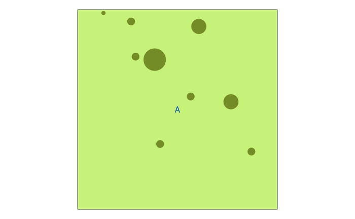

```r
{
# Esparragueras
c_campo <- rgb(0.78, 0.95, 0.48)
c_amg <- rgb(0, 0.31, 0.74)
c_espar <- rgb(0.45, 0.55, 0.15)
esp <- 9
set.seed(12 * 1980)
xe <- runif(esp)
ye <- runif(esp)
re <- round(runif(esp, min = 1, max = 6))
par(pty = "s",
    mar = c(1, 1, 1, 1),
    xaxt = "n", yaxt = "n",
    xaxs = "i", yaxs = "i",
    ann = FALSE)
plot(0, 0,
    xlim = c(0, 1),
    ylim = c(0, 1))
rect(par("usr")[1],
    par("usr")[3],
    par("usr")[2],
    par("usr")[4],
    col = c_campo)
points(xe, ye,
    pch = 19,
    cex = re,
    col = c_espar)
points(0.5, 0.5,
    pch = "A",
    col = c_amg)
}
```

**Figura 2. El prado, las esparragueras y el protagonista.** Los macizos de esparragueras se repartían al azar y en tamaños caprichosos. A, nuestro protagonista, tenía que buscar de una forma a la que no estaba acostumbrado.

**VII**

No tardó en idear un algoritmo de busca y captura con sus limitados conocimientos. Esto fue lo que pensó:

1. *Para empezar, elegiría un punto cardinal al azar.*
2. *Caminaría en esa dirección hasta toparse con una esparraguera.*
3. *Una vez rapiñada, giraría en ángulo recto hacia su derecha y volvería al paso* 2, *en la creencia de habría otra cercana*.

Este método lo leyó alguna vez en una revista de supervivencia, donde se explicaba cómo escaparse de un laberinto. Por lo visto, aunque no fuese la forma más rápida, era la única segura que permitía salir sin perderse. Parecía bastante sistemático. Así, se puso en marcha.

[figure not shown]

**Figura 3. Movimiento de Abundio según su algoritmo.** Suponiendo que empezara mirando al norte, avanzaría dos pasos hasta toparse con una esparraguera. Entonces viraría 90 grados a estribor y avanzaría hasta encontrar la siguiente.

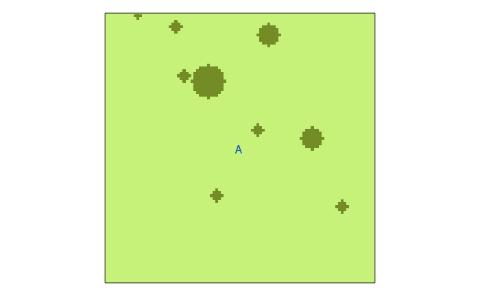

```r
{
#---- Espacio
xmax <- 100  # ancho de la pradera (desde x = 1 hasta x = 100)
ymax <- 100  # largo "        "    (desde y = 1 hasta y = 100)

#---- Pradera vacía
par(pty = "s",
    mar = c(1, 1, 1, 1),
    xaxt = "n", yaxt = "n",
    xaxs = "i", yaxs = "i",
    ann = FALSE)
plot(0, 0,
    xlim = c(1, xmax),
    ylim = c(1, ymax))
rect(par("usr")[1],
    par("usr")[3],
    par("usr")[2],
    par("usr")[4],
    col = c_campo)

#---- Posición de las esparragueras
XYespar <- matrix(0, xmax, ymax)
# pixelar la Figura 2
for (i in 1:esp){
  x <- ceiling(xmax*xe[i])
  y <- ceiling(ymax*ye[i])
  # ¿Cómo pixelar un círculo con teselas de lado = 1?
  for (yi in 0:re[i]){
    y_arr <- y + yi
    if (y_arr > ymax) {y_arr <- y_arr - ymax} # por si se sale
    y_abj <- y - yi
    if (y_abj < 1) {y_abj <- ymax + y_abj}
    borde <- sqrt(re[i]^2 - yi^2)
    for (xi in 0:borde){
      x_der <- x + xi
      if (x_der > xmax) {x_der <- x_der - xmax}
      x_izq <- x - xi
      if (x_izq < 1) {x_izq <- xmax + x_izq}
      points(x_der, y_arr, pch = 15, col = c_espar, cex = 0.6)
      XYespar[x_der, y_arr] <- 1
      points(x_izq, y_arr, pch = 15, col = c_espar, cex = 0.6)
      XYespar[x_izq, y_arr] <- 1
      points(x_der, y_abj, pch = 15, col = c_espar, cex = 0.6)
      XYespar[x_der, y_abj] <- 1
      points(x_izq, y_abj, pch = 15, col = c_espar, cex = 0.6)
      XYespar[x_izq, y_abj] <- 1
    }
  }
}
XYespar_ini <- XYespar # servirá para iniciar la pradera muchas veces

#---- Posición de Abundio
Ax <- ceiling(0.5*xmax)
Ay <- ceiling(0.5*xmax)
points(Ax, Ay,
  pch = "A",
  col = c_amg)
}
```

**Figura 4. La pradera pixelada.** Como Abundio se mueve a pasos, la información de la pradera de la Figura 2 se puede discretizar en píxeles de `1 x 1` paso.

[figure not shown]

**Figura 5. Según donde mire Abundio** su paso siguiente cambiará sus coordenadas en la pradera según una regla muy sencilla.

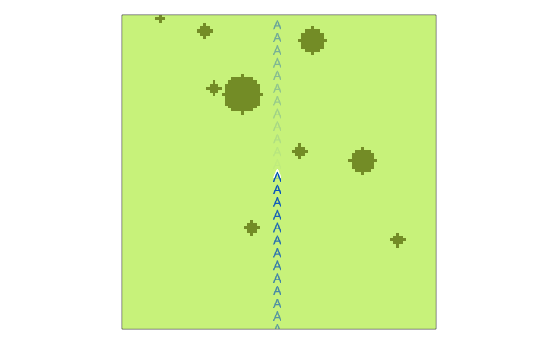

```r
{
#---- Forma de la pradera
par(pty = "s",
    mar = c(1, 1, 1, 1),
    xaxt = "n", yaxt = "n",
    xaxs = "i", yaxs = "i",
    ann = FALSE)

#---- Posición de las esparragueras
image(x = 1:xmax,
    y = 1:ymax,
    XYespar,
    xlim = c(1, xmax),
    ylim = c(1, ymax),
    col = c(c_campo, c_espar))

#---- Posición y orientación de Abundio
Ax <- ceiling(0.5*xmax)
Ay <- ceiling(0.5*xmax)
Ad <- 1
text(Ax, Ay, "A", col = "white")
Ae <- 0 # espárragos recolectados

#---- Movimiento y captura de espárragos
Dx <- c(0, 1, 0, -1) # mira la Figura 5
Dy <- c(1, 0, -1, 0)
rota <- c(0, 270, 180, 90)
pasos <- 100 # pasos

for (t in 2:pasos){

  # Dibujar las esparragueras
  # image(x = 1:100, y = 1:100, XYespar, xlim = c(1,xmax), ylim = c(1,ymax),
  #       col = c(c_campo, c_espar))

  # Abundio se mueve
  Ax <- Ax + Dx[Ad]
  Ay <- Ay + Dy[Ad]
  if (Ax > xmax) {Ax <- 1} # por si se sale
  if (Ax < 1) {Ax <- xmax}
  if (Ay > ymax) {Ay <- 1}
  if (Ay < 1) {Ay <- ymax}

  # Ver si ha encontrado un espárrago
  if (XYespar[Ax,Ay] == 1){
    Ae <- Ae + 1 # lo coge
    Ad <- Ad + 1 # gira 90º a su derecha
    if (Ad > 4) {Ad <- 1}
    XYespar[Ax,Ay] <- 0 # quitamos la esparraguera del prado
  }

  # Dibujamos la nueva posición
  if (t %% 4 == 0){
    text(Ax, Ay, "A",
    col = rgb(0, 0.31, 0.74, alpha = t/pasos),
    srt = rota[Ad])
  }
}
}
```

**Figura 6. Primer paseo de Abundio.** ¡Volvió al punto de partida sin encontrar una sola esparraguera!

**VIII**

—¡He vuelto adonde empecé! —exclamó Abundio al comprobar que, a pesar de haber caminado siempre hacia el norte, había vuelto al punto de partida.

¡Con razón la gente temía aquel lugar! *Las afueras* no tenían límites y, sin embargo, su extensión era limitada. Exactamente 100 pasos en cada dirección, como pudo comprobar. De hecho, si entrecerraba sus párpados para ver a lo lejos, podía ver su propia espalda en cualquier dirección que mirase. ¡¡Qué lugar tan asombroso!!

**IX**

—Tengo que buscar de otra manera menos rígida —pensó Abundio, esforzándose por escapar de sus estrictos axiomas—. Tal vez debería girar a la derecha, de vez en cuando, aunque no encuentre una esparraguera.

Hurgó en el bolsillo izquierdo de su pantalón y sacó un dado que se encontró en la puerta del *Jubileta Bacileta*, víctima sin duda del furor con que allí se jugaba. Recordó su niñez y decidió girar a la derecha cada vez que saliera un cinco, lanzado el dado a cada paso.

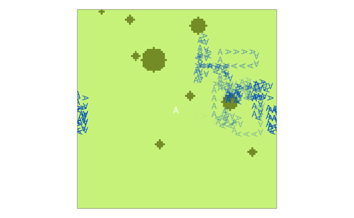

```r
{
#---- Forma de la pradera
par(pty = "s",
    mar = c(1, 1, 1, 1),
    xaxt = "n", yaxt = "n",
    xaxs = "i", yaxs = "i",
    ann = FALSE)

#---- Posición de las esparragueras
XYespar <- XYespar_ini
image(x = 1:xmax,
    y = 1:ymax,
    XYespar,
    xlim = c(1,xmax),
    ylim = c(1,ymax),
    col = c(c_campo, c_espar))

#---- Posición y orientación de Abundio
Ax <- ceiling(0.5*xmax)
Ay <- ceiling(0.5*xmax)
Ad <- 1
text(Ax, Ay, "A", col = "white")
Ae <- 0 # espárragos recolectados

#---- Movimiento y captura de espárragos
Dx <- c(0, 1, 0, -1) # mira la Figura 5
Dy <- c(1, 0, -1, 0)
rota <- c(0, 270, 180, 90)
pasos <- 1000 # pasos

# set.seed(12 * 1980)
for (t in 2:pasos){

  # Dibujar las esparragueras
  # image(x = 1:100, y = 1:100, XYespar, xlim = c(1,xmax), ylim = c(1,ymax),
  #       col = c(c_campo, c_espar))

  # Sale un 5: giro inopinado a la derecha
  if (runif(1) < 0.17) {
    Ad <- Ad + 1 # gira 90º a su derecha
    if (Ad > 4) {Ad <- 1}
  }

  # Abundio se mueve
  Ax <- Ax + Dx[Ad]
  Ay <- Ay + Dy[Ad]
  if (Ax > xmax) {Ax <- 1} # por si se sale
  if (Ax < 1) {Ax <- xmax}
  if (Ay > ymax) {Ay <- 1}
  if (Ay < 1) {Ay <- ymax}

  # Ver si ha encontrado un espárrago
  if (XYespar[Ax,Ay] == 1){
    Ae <- Ae + 1 # lo coge
    Ad <- Ad + 1 # gira 90º a su derecha
    if (Ad > 4) {Ad <- 1}
    XYespar[Ax,Ay] <- 0 # quitamos la esparraguera del prado
  }

  # Dibujamos la nueva posición
  if (t %% 4 == 0){
    text(Ax, Ay, "A",
    col = rgb(0, 0.31, 0.74, alpha = t/pasos),
    srt = rota[Ad])
  }
}
}
```

**Figura 7. Segundo paseo de Abundio.** Ahora giraba a la derecha cada vez que le salía un ⚄ en el dado. En el vídeo de abajo se ve otro paseo que igualmente le podría haber ocurrido ¡en el que no habría pillado un solo espárrago!

[video not shown]

—¡No está mal! —exclamó mirando los 24 espárragos en su mano izquierda.

En ese momento cayó en que se estaba entreteniendo mucho tiempo, no quería llegar tarde a comer. Miró su sombra y comprobó que apenas se había acortado, así que aún le quedaba mucha mañana por delante. Una ráfaga de aire le hizo mirar hacia la rotonda del autobús.

—A ver —y entró de nuevo en la ciudad. Efectivamente, la sombra medía igual sobre el cemento, eso quería decir que era la misma hora que en el prado. Sin embargo, tenía la sensación de que fuera de la ciudad el tiempo pasaba más lentamente. Como no tenía reloj no podía comprobarlo, aunque eso ahora que estaba jubilado no le importaba mucho. Tenía que encontrar una forma mejor para buscar espárragos.

—Esto de girar siempre a la derecha tal vez no sea una buena idea —pensó mientras se colocaba bien el lápiz en la oreja—. A lo mejor, si giro a la izquierda cuando saque un ⚄, puedo tener más opciones —y se puso al lío.

Como era un hombre metódico, repitió 20 veces el paseo con la regla antigua y otras 20 con la nueva regla.

```r
{
# SIN GRÁFICOS, PARA ALIGERAR

veces <- 20
Ae_regla1 <- numeric()
Ae_regla2 <- numeric()

# REGLA ANTIGUA
for (vez in 1:veces){
    #---- Posición de las esparragueras
    XYespar <- XYespar_ini

    #---- Posición y orientación de Abundio
    Ax <- ceiling(0.5*xmax)
    Ay <- ceiling(0.5*xmax)
    Ad <- 1
    Aes <- 0 # espárragos recolectados

    #---- Movimiento y captura de espárragos
    Dx <- c(0, 1, 0, -1) # mira la Figura 5
    Dy <- c(1, 0, -1, 0)
    rota <- c(0, 270, 180, 90)
    pasos <- 1000 # pasos

    for (t in 2:pasos){

      # Sale un 5: giro inopinado a la derecha
      if (runif(1) < 0.17) {
        Ad <- Ad + 1 # gira 90º a su derecha
        if (Ad > 4) {Ad <- 1}
      }

      # Abundio se mueve
      Ax <- Ax + Dx[Ad]
      Ay <- Ay + Dy[Ad]
      if (Ax > xmax) {Ax <- 1} # por si se sale
      if (Ax < 1) {Ax <- xmax}
      if (Ay > ymax) {Ay <- 1}
      if (Ay < 1) {Ay <- ymax}

      # Ver si ha encontrado un espárrago
      if (XYespar[Ax,Ay] == 1){
        Aes <- Aes + 1 # lo coge
        Ad <- Ad + 1 # gira 90º a su derecha
        if (Ad > 4) {Ad <- 1}
        XYespar[Ax,Ay] <- 0 # quitamos la esparraguera del prado
      }
    }
Ae_regla1[vez] <- Aes
}
media_regla1 <- mean(Ae_regla1)
desvi_regla1 <- sd(Ae_regla1)


# REGLA NUEVA
for (vez in 1:veces){
    #---- Posición de las esparragueras
    XYespar <- XYespar_ini

    #---- Posición y orientación de Abundio
    Ax <- ceiling(0.5*xmax)
    Ay <- ceiling(0.5*xmax)
    Ad <- 1
    Aes <- 0 # espárragos recolectados

    #---- Movimiento y captura de espárragos
    Dx <- c(0, 1, 0, -1) # mira la Figura 5
    Dy <- c(1, 0, -1, 0)
    rota <- c(0, 270, 180, 90)
    pasos <- 1000 # pasos

    for (t in 2:pasos){

      # Sale un 5: giro inopinado a la izquierda
      if (runif(1) < 0.17) {
        Ad <- Ad - 1 # gira 90º a su izquierda
        if (Ad < 1) {Ad <- 4}
      }

      # Abundio se mueve
      Ax <- Ax + Dx[Ad]
      Ay <- Ay + Dy[Ad]
      if (Ax > xmax) {Ax <- 1} # por si se sale
      if (Ax < 1) {Ax <- xmax}
      if (Ay > ymax) {Ay <- 1}
      if (Ay < 1) {Ay <- ymax}

      # Ver si ha encontrado un espárrago
      if (XYespar[Ax,Ay] == 1){
        Aes <- Aes + 1 # lo coge
        Ad <- Ad + 1 # gira 90º a su derecha
        if (Ad > 4) {Ad <- 1}
        XYespar[Ax,Ay] <- 0 # quitamos la esparraguera del prado
      }
    }
Ae_regla2[vez] <- Aes
}
media_regla2 <- mean(Ae_regla2)
desvi_regla2 <- sd(Ae_regla2)

}
```

Con la regla antigua cogió una media de 10 espárragos por paseo con una desviación de 7. Con la regla nueva cogió 12 con desviación 7. No parecía una diferencia ostensible, aunque no estaba muy seguro porque las cosas que ocurren al azar nunca le habían parecido muy fiables.

—Todavía es pronto —dijo al mirar su sombra—, voy a hacer más repeticiones —decidió, dispuesto a dar solidez estadística a sus conclusiones.

```
' La naturaleza de estos modelos hace que vayan más lentos que
' *una transfusión de pan rallao*, especialmente en `R` así que habrá
' que buscar una solución.
' Por ejemplo [FreeBASIC](https://www.freebasic.net/) una versión
' remozada de nuestros queridos intérpretes que venían con el MS-DOS.
' Es un lenguaje libre que tiene la ventaja de compilar el código,
' volviéndose rápido como el rayo.  Eso sí, habrá que combinarlo con
' `R` de manera que `FreeBASIC` haga el trabajo duro y el otro saque
' las gráficas y el análisis estadístico, si eso.
'
'
'                              # # # # # # #
'                              #  Y E M A  #   abu00.bas
'                              # # # # # # #
'
' REM GIUSSEPPE
randomize 1981
' screenres 480,480,24

'---- definir variables y tipos

' principales
dim as integer esp, re_min, re_max
dim as integer xmax, ymax
dim as integer pasos
dim as integer veces

'auxiliares
dim as integer i, j, t
dim as integer yi, y_arr, y_abj
dim as integer xi, x_der, x_izq
dim as integer borde
dim as integer vez

'------- leer coeficientes y condiciones de simulación

open "coef_abu00.txt" for input as #1
input #1, esp
print "esp: "; esp
input #1, re_min
```

[output cut: 152 more lines]

```
            Ad = Ad + 1 ' gira 90º a su derecha
            if Ad > 4 then Ad = 1
            XYespar(Ax,Ay) = 0 'quitamos la esparraguera del prado
        end if

    next t

    '---- grabar los datos
    print #1, Ae

next vez

close #1

' sleep
```

```r
                              # # # # # # # #
                              #  C L A R A  #
                              # # # # # # # #

esp <- 9           # número de esparragueras
re_min <- 1        # radio mínimo de la esparraguera
re_max <- 6        #   "   máximo   "

#---- Espacio
xmax <- 100        # ancho de la pradera (desde x = 1 hasta x = 100)
ymax <- 100        # largo        "

#---- Paseo
pasos <- 1000

#---- Repeticiones
veces <- 10000

#---- pasar los coeficientes
write(esp, "coef_abu00.txt")
write(re_min, "coef_abu00.txt", append = TRUE)
write(re_max, "coef_abu00.txt", append = TRUE)
write(xmax, "coef_abu00.txt", append = TRUE)
write(ymax, "coef_abu00.txt", append = TRUE)
write(pasos, "coef_abu00.txt", append = TRUE)
write(veces, "coef_abu00.txt", append = TRUE)

#---- pasar la matriz de esparragueras
write(XYespar_ini, "XYesp_abu00.txt", ncolumns = xmax)

#---- llamar a la yema
system("./abu00")
```

```
esp:  9
re_min:  1
re_max:  6
xmax:  100
ymax:  100
pasos:  1000
veces:  10000
```

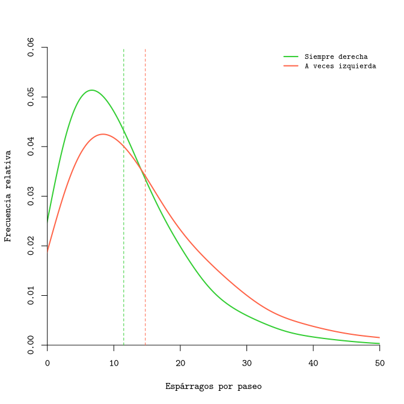

```r
#---- ver los resultados
abu00d <- (read.csv("abu00d.txt"))
media_r1 <- mean(abu00d$Ae)

abu00i <- (read.csv("abu00i.txt"))
media_r2 <- mean(abu00i$Ae)
{
par(family = "LM Mono 8")
plot(density(abu00d$Ae, 3),
    col = "limegreen", lwd = 2,
    xlim = c(0,50),
    ylim = c(0, 0.060),
    main = "",
    xlab = "Espárragos por paseo",
    ylab = "Frecuencia relativa",
    xaxs = "i",
    yaxs = "i",
    bty = "n")
abline(v = media_r1,
    lty = 2,
    col = "limegreen")
lines(density(abu00i$Ae, 3),
    col = "tomato",
    lwd = 2)
abline(v = media_r2,
    lty = 2,
    col = "tomato")
legend("topright",
    c("Siempre derecha", "A veces izquierda"),
    lwd = 2,
    col = c("limegreen", "tomato"),
    cex = 0.8,
    bty = "n")
}
```

**Figura 8. Después de veinte mil paseos,** Abundio comprobó la nueva estrategia era un poco mejor. Ahora conseguía una media de 15 espárragos frente a los 11 de antes.

—Efectivamente —se dijo a sí mismo, sin mostrar atisbo de cansancio a pesar de haber estado una barbaridad de tiempo dando bandazos—, la cosa ha mejorado un poco, aunque el Ozeíllo debe de tener otro sistema, a ver si aparece por aquí y le pregunto.

**X**

Un rugido de tripas le recordó la hora de comer. Miró de nuevo su sombra igual de estirada sobre el prado, habría dicho que no se había acortado lo más mínimo; sin embargo, empezaba a tener hambre. Volvió a la rotonda del autobús, a ver si veía algún kiosquillo pa comprarse un flan-golosina y un revuelto. La rotonda seguía tan desierta como antes, de hecho, parecía que el autobús acababa de irse después del $n$ trayecto, porque aún olía la tufará de gasoil.

—Bueno —se consoló—, tampoco creo que el conductor me hubiera dado muchas indicaciones, y la hora, menos —y pensó en cuantas vueltas habría dado el conductor durante el tiempo que estuvo en el prado. Pobre.

Se atrevió a dar una vuelta por los alrededores, en busca del kiosquillo, y pudo percibir otra vez el agradable olor de los naranjos mañaneros.

—Qué raro… parece como si todavía fuese temprano, ya debe de ser la hora de comer —pensó mientras caminaba por las humildes y bonitas calles sin encontrarse todavía con nadie.

Las aceras aún tenían las baldosas grises que tapizaron por doquier los barrios que surgieron cuando Abundio era chico. Eran una especie de rosas en cemento gris, con cuatro pétalos rectangulares rodeando un cuadrado central.

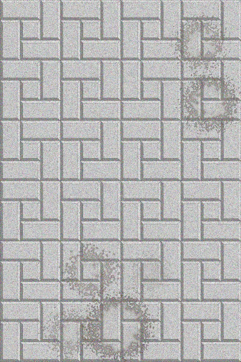

**Figura 9. La acera de los setenta.** A pesar de su edad aún desempeñaba correctamente su función.

Se quedó un poco hipnotizado por la evocación de su niñez y el patrón periódico de las losetas, que parecían llevarle de nuevo a su antiguo colegio. Los recuerdos eran vívidos aunque imperfectos porque le pareció notar algo raro en aquella acera y en aquel momento no supo decir qué. Después de rodear la manzana sin éxito se tuvo que olvidar del piscolabis y decidió volver al prado.

**XI**

La pradera parecía la misma pero también notó algo raro, como si se hubiesen cambiado las plantas de sitio. Juraría que ese árbol chiquitillo lleno de frutas anaranjadas estaba más lejos de la rotonda cuando se fue a buscar el kiosquillo. Se acercó para mirarlo mejor y vio que no era un naranjo, aunque las hojas se parecían mucho. Los frutos, además, eran mucho más pequeños y tenían pelusa en vez de la piel cerúlea de las naranjas. También eran un poco más amarillos.

—¿Se comerán? —se preguntó al son del runrún estomacal, sujetando entre pulgar e índice una de las apetitosas bolillas. A la media vuelta, se soltó de la rama, la limpió con la camiseta y, sin más miramientos, le metió un bocado a un cuarto de diámetro que lo salvó de chiripa del hueso central.

Se comió por lo menos siete unidades. Como estaban tan dulces pensó que no serían tóxicas, según su instinto animal acumulado por selección natural. Cuando iba a por la octava, se llevó un repullo:

—¡Qué, están güenos los amasquillos, ein? —bramó alguien a sus espaldas.

—¡Señor Ozeíllo! —saludó el sorprendido Abundio con unos pellejillos aún entre los dientes.

—Coma, coma, questán mu güenos —dijo el Ozeíllo a la vez que se apuntaba a la rapiña de amasquillos que, según él, era como se llamaban aquellas frutillas.

Compartir almuerzo parece que da confianza entre comensales y pronto se entabló una amena conversación entre ambos.

—¡Que va! —respondió Ozeíllo a la pregunta de si vivía por allí cerca— ¡Yo vivo en la otra punta, lo que pasa es que me gusta venir toas las mañanas!

—A por espárragos, ¿no?

—A por lo que encarte —dijo Ozeíllo con campechanía—. Yo me vengo pacá a echá un rato y aluego tiro pa la peña.

—¿Le puedo hacer una pregunta? —dudó Abundio si encontraría una respuesta adecuada, después de su experiencia en el *Jubileta Bacileta*.

—Pos claro, venga.

—Aquellos dos que se ven a lo lejos somos nosotros, ¿no? —preguntó finalmente Abundio, después del instante dubitativo.

—¡¡Güeeeeeee!! —gritó el Ozeíllo haciendo aspavientos con el brazo derecho. Una de las figuras en lontananza hizo exactamente lo mismo y, al poco, pudieron escuchar el eco del Ozeíllo, aunque parecía venir por detrás de ellos.

—¿Somos nosotros? —volvió a preguntar el atónito Abundio, que no comprendía el experimento del Ozeíllo.

—Pos claro —dijo taxativamente Ozeíllo—, qué pasa, que lestraña ein? Es uno de los efectos del toro masivo que hay por aquí.

—¡Ah! —exclamó Abundio asustado, mirando a todos lados esperando una cornada por la retaguardia— ¿Un toro? ¿Por aquí suelto?

—No se preocupe, hombre, no es de esa clase de toros. Se trata de una gran acumulación de masa en forma de rosco —dijo el Ozeíllo dibujando una «O» en el aire—. Por culpa de su gravedad, el espacio que ocupa esta pradera está tan curvado que se cierra sobre sí mismo. Por eso no vemos los bordes y, por mucho que caminemos, siempre volvemos al mismo sitio. A la luz y al sonido les pasa igual, claro.

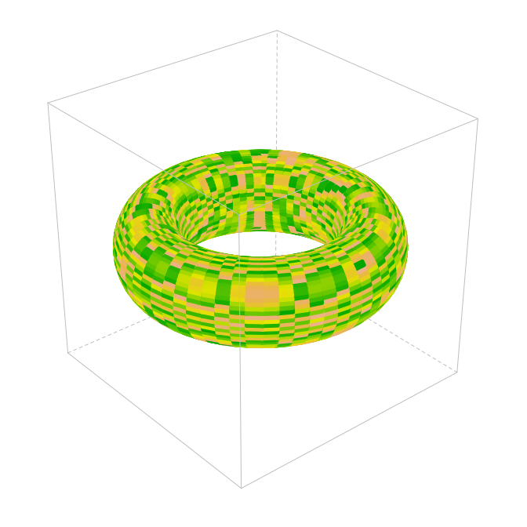

```r
library(lattice)
margen <- list(
    layout.heights = list(
        top.padding = -10,
        main.key.padding = 0,
        key.axis.padding = 0,
        axis.xlab.padding = 0,
        xlab.key.padding = 0,
        key.sub.padding = 0,
        bottom.padding = -10),
    layout.widths = list(
        left.padding = -10,
        key.ylab.padding = 0,
        ylab.axis.padding = 0,
        axis.key.padding = 0,
        right.padding = -10),
    axis.line = list(col = "transparent"))
t <- seq(0, 2*pi, length.out = 65)
u <- seq(0, 2*pi, length.out = 65)
R <- 4
r <- 1.2
xm <- outer(t, u, function(t, u) cos(t)*(R + r*cos(u)))
ym <- outer(t, u, function(t, u) sin(t)*(R + r*cos(u)))
zm <- outer(t, u, function(t, u) r*sin(u))
wireframe(zm ~ xm + ym,
    scales = list(draw = FALSE),
    xlab = "",
    ylab = "",
    zlab = "",
    zlim = c(-4, 4),
    lwd = 5,
    col = terrain.colors(128),
    par.settings = margen,
    par.box = list(col = "grey"),
    shade = TRUE,
    light.source = c(10 ,0, 10))
```

**Figura 10. La extraña pradera de *las afueras*** debía de estar plegada en otra dimensión, de manera que Abundio podía caminar en cualquier dirección sin encontrar el borde. Como la luz y el sonido tampoco percibirían esa otra dimensión, su trayectoria rectilínea acabaría también allá donde empezaran y por eso Abundio y el Ozeíllo se veían y oían a sí mismos (si gritaban lo suficiente, claro).

Abundio se quedó tan sorprendido por la explicación como por haberla oído salir de la boca del Ozeíllo. No pegaban aquellas ideas con el aspecto de quién las decía, blasonado por una gran hebilla de dos trabas en la vanguardia de una magnánima barriga, desde donde caían los pantalones vaqueros a plomo sobre unas churretosas «tórtolas» azules de cordones blancos. Una camisa de cuadros por la que se abrían paso hirsutas mechas aprovechando los huecos desabotonados y una gorra amarilla de propaganda de *Perespilsa* completaban la vestimenta del Ozeíllo. Ahora que se fijaba bien en su cara sonrosada, pudo ver un brillo de picardía en sus ojos grises, entre unos párpados tan rechonchos que apenas dejaban una rendija para la pupila.

—Entonces, ¿si hago un agujero aquí llegaré al toro masivo? —dijo Abundio pateando dos veces el suelo, imaginándose esa masa colosal como el relleno de un dónut.

—Nanai, por mucho que escarbe usté, escarbará en tres dimensiones. Mire hacia arriba, mire —dijo el Ozeíllo con el índice alzado.

Abundio miró al cielo y casi se cae de la impresión: allí estaban el Ozeíllo y él, mirando hacia abajo con los pies pegados a un prado cenital idéntico al que pisaban.

—¡¡Güeeeeeee!! —repitió alegremente el Ozeíllo haciéndose señas a su sí mismo ortogonal, y añadió despreocupado:— Esa materia, en su mayor parte, está en otra dimensión y, encima, es materia oscura —explicó el Ozeíllo.

—«Otra dimensión», «materia oscura», jé… —repuso aún aturdido Abundio, que podía ser crédulo e impresionable pero también difícil de engatusar.

—¡Sí hombre! La otra dimensión es necesaria para plegar la pradera en una forma cerrada —explicó Ozeíllo sin perder el acento— igual que necesitamos dos dimensiones para cerrar un hilo en forma de circunferencia, o tres dimensiones para cerrar un papé en forma de bola, necesitamos al menos una cuarta dimensión para cerrar esta pradera.

—Bueno —transigió Abundio—, lo comprendo pero no me lo imagino, no puedo verlo.

—Nadie puede verlo, no se preocupe usté, aunque podemos estudiar las propiedades matemáticas y comprender su topología —dijo el Ozeíllo enarcando una ceja y guiñando el ojo de la otra.

—¿Usted es matemático?

—Sí —respondió Ozeíllo con cierta tristeza—, bueno, lo era antes. Ahora soy un cateto y me va mejor.

—Vaya —dijo Abundio en una duda empática, no sabía si alegrarse o condolerse del Ozeíllo.

—No pasa ná, hombre —continuó el Ozeíllo—. De chico me encantaban las matemáticas y por eso hice la carrera. No me fue mal en la profesión, porque acabé de profesor en *la Sorrona* pero el tema se fue estropeando y decidí echarme al monte.

—Ya entiendo —dijo Abundio, aunque en realidad no entendía que un profesor de tan prestigiosa universidad decidiera abandonar su trabajo para coger espárragos. Con lo que le gustaban los números, estuvo a punto de proponerle que le pusiera una multiplicación difícil cuando el Ozeíllo cambió precipitadamente de tema.

—Perdonusté, que voy a equilibrar el balance de masa.

—¿Cómo dice? —preguntó Abundio.

—Que voy a iñar, que los amasquillos yastán haciendo efecto —dijo el Ozeíllo mientras se iba soltando la correa camino de un arbusto con bolas rojas.

—¿Y la materia oscura? —preguntó Abundio, que no sabía si seguir la conversación o esperar a que acabase la maniobra de exoneración.

—¿Ha visto qué tomatera tan güena ha salío aquí? —gritó el Ozeíllo detrás de las matas—. Lo de la materia oscura, si eso se viene usté a la peña aluegodespué y el Esteban y el Juáquin se losplican.

—¿También son matemáticos como usted?

—¡Iiiinng… ñáh! ¡Toma materia oscura! —dijo el Ozeíllo asomando la cabeza, y siguió mientras se subía los calzones—: No, no, ellos son físicos teóricos, lo que pasa es que ahora están enviciaos con el dómino y son unos malapipa, sobretó el cabezón.

—Bueno, vale —dijo Abundio, con cierto hormigueo de curiosidad.— ¿No se nos hará tarde?

—No se procupusté —contestó el Ozeíllo restregándose las manos con unos tallos verdes que había arrancado de otro arbusto—. Hinojo, que limpia y güele bien. Llegaremos bien, toavía es temprano y aquí el tiempo va mu lento.

—¡Es verdad! —exclamó Abundio, al comprobar que su sensación del tiempo era cierta.

—La masa del toro, aparte de plegar el espacio, hace que el tiempo vaya más despacio, según la paradoja de Esteban-Juáquin.

—¿La paradoja de Esteban-Juáquin? —preguntó Abundio, que había vuelto a cobrar interés.

—Sí —explicó el Ozeíllo— aquí donde estamos tenemos la sensación de que el tiempo pasa normalmente, pero cuando volvemos a la ciudad nos damos cuenta de que es prácticamente la misma hora que cuando entramos en el prado.

—Es paradójico, ciertamente —afirmó Abundio intentando llevar el hilo.

—Espéresusté que, aunque raro, esa no es la paradoja —dijo el Ozeíllo—, según la teoría de la relatividad, el tiempo fuera de la pradera pasaría mucho más rápido que aquí si esta enorme masa que pliega la pradera fuese de materia normal, y es justo al revés, ¡esa es la paradoja! Así que debe tratarse de materia oscura, según dedujeron el cabezón canoso y el íopuchi del canihillo. Los mamones salieron en el canalsú y tó.

—Ya veo —dijo Abundio, al que le pareció percibir cierto tono de envidia en las últimas palabras del Ozeíllo.

—¡Bueno, menos rollo y más mantecalbollo, a vé que hay por aquí hoy!

**XII**

El Ozeíllo dio una docena de pasos hacia el norte y enseguida empezó a caminar haciendo caracolillos. A Abundio, que iba a su lado, le parecía que repetían el mismo rizo una vez y otra, pero no debía de ser así porque estaban encontrando muchos más espárragos.

—¡Es usted un máquina, oiga! —piropeó Abundio, incapaz de quedarse con la pauta del paseo. Le pareció que el Ozeíllo trazaba una espiral más grande compuesta por espirales más pequeñas.

—Esto es pa echá el rato, con lo que saco me compro mi paquetillo de «Grávena» y poco má —respondió el Ozeíllo mientras se agachaba para cortar un par de hermosos ejemplares con su navajilla.

Al cabo de media hora, como mucho, la gomilla que sujetaba el manojo ya no daba más de sí, y el lomo del Ozeíllo tampoco.

—Bueno amigo, yo me voy pa la peña, ¿se vienusté? —preguntó el Ozeíllo secándose la sonriente y sudorosa cara colorada con la bocamanga de la camisa.

Abundio dudó otra vez. Por una parte estaba intrigado con el asunto del toro y la materia oscura y, por otro lado, aún seguía ilusionado con su primera estancia en *las afueras*. Finalmente, como temía no encajar en el *Jubileta Bacileta*, decidió quedarse en el prado.

—Gracias por su amable invitación, pero me voy a quedar un rato más a ver si aprendo a buscar espárragos.

—Vale, queeustécondió —se despidió Ozeíllo— pero ande con cuidao que esto cambia envéencuando.

—Vale, gracias.

**XIII**

Se quedó de nuevo solo en la pradera.

—Tiene que haber alguna manera de encontrar la mejor estrategia, a ver si se me ocurre algo.

Se sentó en una gran losa de mármol de la que no se había percatado hasta entonces y sacó el dado del bolsillo. Cogió un palillo seco y empezó a dibujar en el suelo delante de sus pies.

Allí sentado a la sombrita del amasquillo se estaba de P. M. Entonces, se quedó dormido.

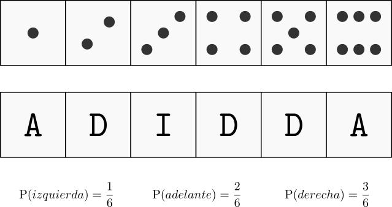

**Figura 11. Lo que dibujó Abundio.** Como se quedó dormido, en su sueño veía ecuaciones muy bonitas.

Soñó que asignaba un movimiento (derecha, adelante, izquierda) a cada cara del dado. Así, en vez girar a la izquierda cuando salía un ⚄ y girar a la derecha cuando encontraba un espárrago, ahora era más divertido porque había más posibilidades.

Al principio, puso `ADIDDA` porque le recordaba a sus tenis del colegio, pero le pareció que la distribución de probabilidad estaba injustamente sesgada (Figura 11), así que probó con `IIAADD` y ahora le parecía demasiado sosa. Estuvo probando más combinaciones, como `AAAAIA` que se parecía a la última estrategia que usó, aunque ningún anagrama le gustaba ni encontraba justificación en su mente cartesiana.

```
'                            # # # # # # # # #
'                            #  Y E M A   2  #   abu02.bas
'                            # # # # # # # # #
'
' REM GIUSSEPPE
randomize 1981

'---- definir variables y tipos

' principales
dim as integer esp, re_min, re_max
dim as integer xmax, ymax
dim as integer pasos
dim as integer veces

'auxiliares
dim as integer i, j, t
dim as integer yi, y_arr, y_abj
dim as integer xi, x_der, x_izq
dim as integer borde
dim as integer vez
dim as integer cara
dim as string dado, mueve

'------- leer coeficientes y condiciones de simulación

open "coef_abu02.txt" for input as #1
input #1, esp
print "esp: "; esp
input #1, re_min
print "re_min: "; re_min
input #1, re_max
print "re_max: "; re_max
input #1, xmax
print "xmax: "; xmax
input #1, ymax
print "ymax: "; ymax
input #1, pasos
print "pasos: "; pasos
input #1, veces
```

[output cut: 90 more lines]

```

        ' ver si ha encontrado un espárrago
        if XYespar(Ax,Ay) = 1 then
            Ae = Ae + 1 ' lo coge
            XYespar(Ax,Ay) = 0 'quitamos la esparraguera del prado
        end if

    next t

    '---- grabar los datos
    print #1, Ae

next vez

close #1
```

```r
                              # # # # # # # #
                              #  C L A R A  #   versión 2
                              # # # # # # # #

esp <- 9           # número de esparragueras
re_min <- 1        # radio mínimo de la esparraguera
re_max <- 6        #   "   máximo   "

#---- Espacio
xmax <- 100        # ancho de la pradera (desde x = 1 hasta x = 100)
ymax <- 100        # largo        "

#---- Paseo
pasos <- 1000

#---- Repeticiones
veces <- 10000

#---- Regla
dado = "ADIDDA"

#---- pasar los coeficientes
write(esp, "coef_abu02.txt")
write(re_min, "coef_abu02.txt", append = TRUE)
write(re_max, "coef_abu02.txt", append = TRUE)
write(xmax, "coef_abu02.txt", append = TRUE)
write(ymax, "coef_abu02.txt", append = TRUE)
write(pasos, "coef_abu02.txt", append = TRUE)
write(veces, "coef_abu02.txt", append = TRUE)
write(dado, "coef_abu02.txt", append = TRUE)

#---- pasar la matriz de esparragueras
write(XYespar_ini, "XYesp_abu00.txt", ncolumns = xmax)


#---- llamar a la nueva yema
system("./abu02")
```

```
esp:  9
re_min:  1
re_max:  6
xmax:  100
ymax:  100
pasos:  1000
veces:  10000
dado: ADIDDA
```

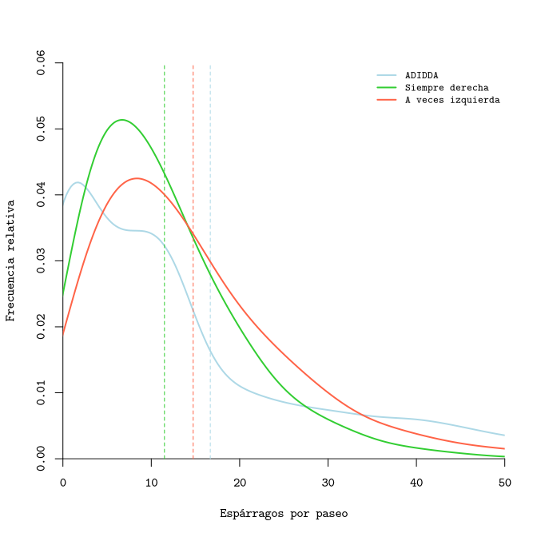

```r
#---- ver los resultados
abu02 <- (read.csv("abu02.txt"))
media_r02 <- mean(abu02$Ae)

{
par(family = "LM Mono 8")
plot(density(abu02$Ae, 3),
    col = "lightblue",
    lwd = 2,
    xlim = c(0, 50),
    ylim = c(0, 0.060),
    main = "",
    xlab = "Espárragos por paseo",
    ylab = "Frecuencia relativa",
    xaxs = "i", yaxs = "i",
    bty = "n")
abline(v = media_r02,
    lty = 2,
    col = "lightblue")
lines(density(abu00d$Ae, 3),
    col = "limegreen",
    lwd = 2)
abline(v = media_r1,
    lty = 2,
    col = "limegreen")
lines(density(abu00i$Ae, 3),
    col = "tomato",
    lwd = 2)
abline(v = media_r2,
    lty = 2,
    col = "tomato")
legend("topright",
    c(dado, "Siempre derecha", "A veces izquierda"),
    lwd = 2,
    col = c("lightblue", "limegreen", "tomato"),
    cex = 0.8,
    bty = "n")
}
```

```
esp:  9
re_min:  1
re_max:  6
xmax:  100
ymax:  100
pasos:  1000
veces:  10000
dado: IIAADD
esp:  9
re_min:  1
re_max:  6
xmax:  100
ymax:  100
pasos:  1000
veces:  10000
dado: AAAAIA
esp:  9
re_min:  1
re_max:  6
xmax:  100
ymax:  100
pasos:  1000
veces:  10000
dado: AAAADA
```

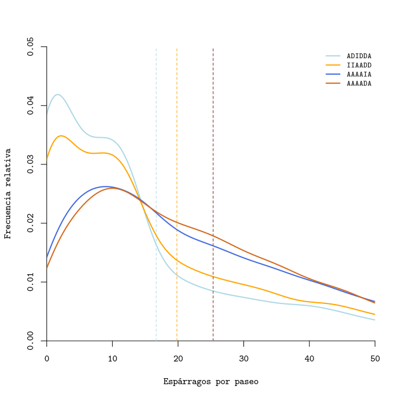

**Figura 13. Tanteando con distintas reglas** mejoró bastante el rendimiento de la cosecha onírica.

Resultó que moverse siempre adelante y, de vez en cuando, girar hacia un lado (siempre el mismo) funcionaba mucho mejor que otras reglas, aparentemente, más estratégicas. El sueño empezaba a convertirse en pesadilla.

**XIV**

Sin saber de dónde, de repente aparecieron el Javié, el Manolo, el Antoñito, el Fali, el Juanjosé, el Rafa, el Ávila, el Codina, el Paquito, el Garcíaluque, el Durán y algunos más que venían a lo lejos.

—¡Qué pasa, pringui! —le dijeron en tono jocoso—. ¡Te has perdío un partío de muerte!

—¡Es que con las chancletas no podía, hombre! —respondió Abundio que, efectivamente, iba en chancletas.

—¿Que estás haciendo aquí sentao? —le preguntó el Manolo, sentándose a su lado.

—Estaba pensando en un juego nuevo —dijo Abundio guiñando un ojo.

—¿Apedreamos a los del callejón? —propuso el Fali, dándole una patada a una naranja que fue a impactar contra el marmolillo donde se estaban sentando todos.

—Déate rollo —dijo el Antoñito, que siempre salía escalabrao en las reyertas paleolíticas.

—¿Cómo es el juego? —preguntó el Garcíaluque, al que le gustaban las ocurrencias del Abundio.

—Es el `ju-e-go-de-lo-sau-tó-ma-tas` —dijo Abundio en un tono robotizado.

—¡Es un juego de pringaos! —exclamó el Paquito— ¡Vamos a apedrear al Anné!

—¡Pero si no sabes cómo es, chalao! —dijo el Codina— ¿No ves que es un juego nuevo, maharón?

—Maharón tú, chalao.

—Vamos a jugar un rato y, si es un rollo, después apedreamos a la banda del Célula —propuso el Rafa.

—A vé —empezó a explicar Abundio—. Cada uno de nosotros es un autómata y tenemos que seguir estrictamente nuestra programación. El que encuentre más espárragos se gana un flan-golosina.

—O un revuelto, ¿vale? —propuso el Javié, que era más de kikos.

Abundio repartió doce dados y doce cartoncillos. Cada uno escribió las seis letras que le pareció y empezaron a jugar.

```
'                            # # # # # # # # #
'                            #  Y E M A   3  #   abu03.bas
'                            # # # # # # # # #
'
' REM GIUSSEPPE
randomize 1981
' screenres 100, 100, 8

data "Javié", "Manolo", "Antoñito", "Fali", "Juanjosé", "Rafa"
data "Ávila", "Codina", "Paquito", "Garcíaluque", "Durán", "Abundio"
data "Juanín", "Kiko", "Juanma", "Célula", "Mocoso", "Carahuevo"
data "Charlesboyer", "Carlos", "Lepe", "Joselete", "Zambrano", "Galán"
data "González", "Román", "Bellido", "Pérez", "Álvarez", "Martín"
data "Vargas", "Núñez", "Carri", "Cuevas", "Cruzado", "Finley"
data "Escudero", "Matas", "Monti", "Lara", "Iorfida", "Bernabé"


'---- definir variables y tipos

' principales
dim as integer esp, re_min, re_max
dim as integer xmax, ymax
dim as integer pasos
dim as integer veces

'auxiliares
dim as integer i, j, t
dim as integer yi, y_arr, y_abj
dim as integer xi, x_der, x_izq
dim as integer borde
dim as integer vez
dim as integer cara
dim as string mueve
dim as integer n_amigos
dim as integer maximo, amigo_max, minimo, amigo_min
dim as string flangolosina, flangolosina_n, pringao, pringao_n

'------- leer coeficientes y condiciones de simulación

open "coef_abu03.txt" for input as #1
```

[output cut: 145 more lines]

```
    next i
    flangolosina = carton(amigo_max)
    flangolosina_n = Nombre(amigo_max)
    pringao = carton(amigo_min)
    pringao_n = Nombre(amigo_min)
    ' print "máximo: "; maximo; "  "; flangolosina; "  "; flangolosina_n
    ' print "mínimo: "; minimo; "  "; pringao; "  "; pringao_n
    'sleep

    '---- grabar los datos
    print #1, vez, minimo, pringao, pringao_n, maximo, flangolosina, flangolosina_n

next vez

close #1
```

```r
                              # # # # # # # #
                              #  C L A R A  #   versión 3
                              # # # # # # # #

esp <- 9           # número de esparragueras
re_min <- 1        # radio mínimo de la esparraguera
re_max <- 6        #   "   máximo   "

#---- Espacio
xmax <- 100        # ancho de la pradera (desde x = 1 hasta x = 100)
ymax <- 100        # largo        "

#---- Paseo
pasos <- 1000

#---- Repeticiones
veces <- 10

#---- Amigos
n_amigos <- 12

#---- pasar los coeficientes
write(esp, "coef_abu03.txt")
write(re_min, "coef_abu03.txt", append = TRUE)
write(re_max, "coef_abu03.txt", append = TRUE)
write(xmax, "coef_abu03.txt", append = TRUE)
write(ymax, "coef_abu03.txt", append = TRUE)
write(pasos, "coef_abu03.txt", append = TRUE)
write(veces, "coef_abu03.txt", append = TRUE)
write(n_amigos, "coef_abu03.txt", append = TRUE)

#---- pasar la matriz de esparragueras
write(XYespar_ini, "XYesp_abu00.txt", ncolumns = xmax)


#---- llamar a la nueva yema
system("./abu03")
```

```
esp:  9
re_min:  1
re_max:  6
xmax:  100
ymax:  100
pasos:  1000
veces:  10
número de amigos:  12
```

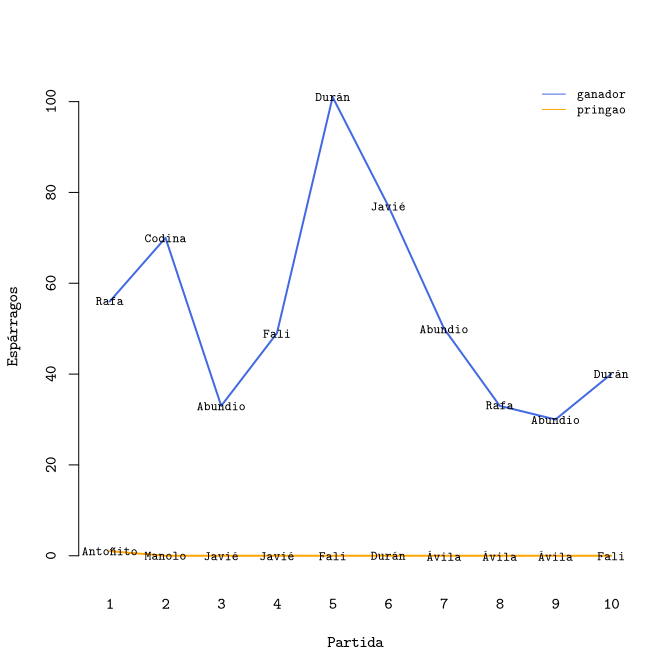

```r
#---- ver los resultados
abu03 <- read.csv("abu03.txt", sep = "")
{
par(family = "LM Mono 8")
plot(abu03$Max,
    type = "l",
    lwd = 2,
    col = "royalblue",
    xlim = c(0.81, 10),
    ylim = c(0, max(abu03$Max)),
    ylab = "Espárragos",
    xlab = "Partida",
    xaxt = "n",
    bty = "n")
axis(1,
    at = 1:n_amigos,
    labels = 1:n_amigos,
    col = 0)
legend("topright",
    c("ganador", "pringao"),
    col = c("royalblue", "orange"),
    lty = 1,
    bty = "n",
    cex = 0.8)
text(1:100,
    abu03$Max,
    abu03$Flangolosina,
    cex = 0.8)
lines(abu03$Min,
    lwd = 2,
    col = "orange")
text(1:100,
    abu03$Min,
    abu03$Pringao,
    cex = 0.8)
}
```

**Figura 14. Las diez primeras partidas.** Algunos tuvieron más suerte que otros, aunque no siempre fueron el mismo. ¡Y casi siempre había alguien que no pillaba ni uno!

**XV**

Las primeras diez partidas fueron honestas, pero enseguida empezaron las tranfullas. El que perdía miraba de reojo el cartón del ganador y copiaba algunas letras, pero casi nunca las podía copiar todas, así que rellenaba el resto con las letras de otro jugador, el que pillara.

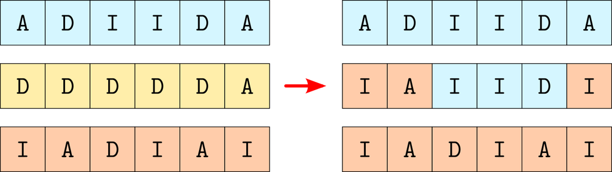

**Figura 15. El que perdía sacaba sus artes de tranfullero** y copiaba algunas letras del cartón ganador, las que podía, completándolas con las de otro amigo que se pusiera a tiro.

```
'                            # # # # # # # # #
'                            #  Y E M A   4  #   abu04.bas
'                            # # # # # # # # #
'
' REM GIUSSEPPE
randomize timer
' screenres 100, 100, 8

data "Javié", "Manolo", "Antoñito", "Fali", "Juanjosé", "Rafa"
data "Ávila", "Codina", "Paquito", "Garcíaluque", "Durán", "Abundio"
data "Juanín", "Kiko", "Juanma", "Célula", "Mocoso", "Carahuevo"
data "Charlesboyer", "Carlos", "Lepe", "Joselete", "Zambrano", "Galán"
data "González", "Román", "Bellido", "Pérez", "Álvarez", "Martín"
data "Vargas", "Núñez", "Carri", "Cuevas", "Cruzado", "Finley"
data "Escudero", "Matas", "Monti", "Lara", "Iorfida", "Bernabé"


'---- definir variables y tipos

' principales
dim as integer esp, re_min, re_max
dim as integer xmax, ymax
dim as integer pasos
dim as integer veces

'auxiliares
dim as integer i, j, t
dim as integer yi, y_arr, y_abj
dim as integer xi, x_der, x_izq
dim as integer borde
dim as integer vez
dim as integer cara
dim as string mueve
dim as integer n_amigos
dim as integer maximo, amigo_max, minimo, amigo_min, media
dim as string flangolosina, flangolosina_n, pringao, pringao_n
dim as integer pc, fc, amigo_azar
dim as integer diversidad, nuevo

'------- leer coeficientes y condiciones de simulación
```

[output cut: 205 more lines]

```
    ' print "mínimo: "; minimo; "  "; pringao; "  "; pringao_n
    'sleep

    '---- grabar los datos
    print #1, vez, minimo, pringao, pringao_n, maximo, flangolosina, flangolosina_n, media, diversidad

next vez

 close #1

print
print "CARTONES FINALES"
for i = 1 to n_amigos
    print carton(i)
next i
```

```r
                              # # # # # # # #
                              #  C L A R A  #   versión 4
                              # # # # # # # #

esp <- 9           # número de esparragueras
re_min <- 1        # radio mínimo de la esparraguera
re_max <- 6        #   "   máximo   "

#---- Espacio
xmax <- 100        # ancho de la pradera (desde x = 1 hasta x = 100)
ymax <- 100        # largo        "

#---- Paseo
pasos <- 1000

#---- Repeticiones
veces <- 250

#---- Amigos
n_amigos <- 12

#---- pasar los coeficientes
f_coef <- "coef_abu04.txt"
write(esp, f_coef)
write(re_min, f_coef, append = TRUE)
write(re_max, f_coef, append = TRUE)
write(xmax, f_coef, append = TRUE)
write(ymax, f_coef, append = TRUE)
write(pasos, f_coef, append = TRUE)
write(veces, f_coef, append = TRUE)
write(n_amigos, f_coef, append = TRUE)

#---- pasar la matriz de esparragueras
write(XYespar_ini, "XYesp_abu00.txt", ncolumns = xmax)


#---- llamar a la nueva yema
system("./abu04")
```

```
esp:  9
re_min:  1
re_max:  6
xmax:  100
ymax:  100
pasos:  1000
veces:  250
número de amigos:  12

CARTONES INICIALES
AAAADI
AIDDAI
ADDAAA
DIADAD
AAAIDA
AIADDD
IDDDAI
IADDAI
DIDDDI
DAAIAA
DAAIDI
ADDIAD

CARTONES FINALES
DAAIAA
DAAIAA
DAAIAA
DAAIAA
DAAIAA
DAAIAA
DAAIAA
DAAIAA
DAAIAA
DAAIAA
DAAIAA
DAAIAA
```

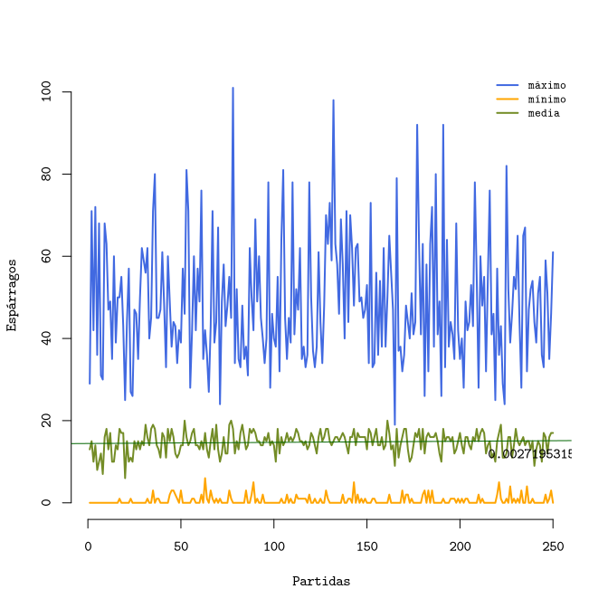

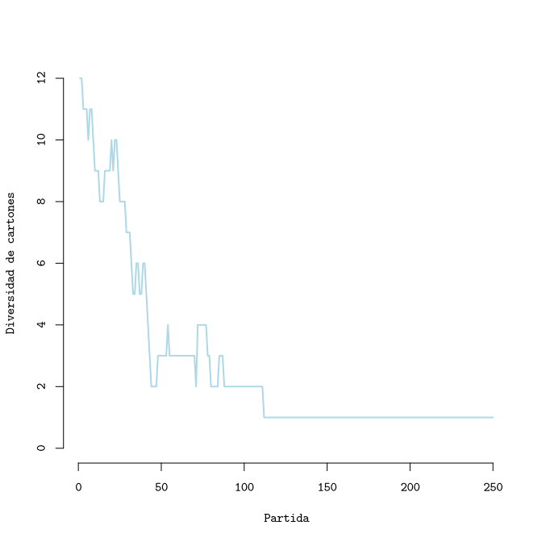

```r
#---- ver los resultados
abu04 <- (read.csv("abu04.txt", sep=""))
{
par(family = "LM Mono 8", bty = "n")
plot(abu04$Max,
    type = "l",
    lwd = 2,
    col = "royalblue",
    ylim = c(0, max(abu04$Max)),
    ylab = "Espárragos",
    xlab = "Partidas")
# text(1:100, abu04$Max, abu04$Flangolosina, cex = 0.8)
lines(abu04$Min,
    lwd = 2,
    col = "orange")
lines(abu04$Media,
    lwd = 2,
    col = c_espar)

ajuste1 <- lm(abu04$Media ~ abu04$Ae)
abline(ajuste1, col = "darkgreen")
text(veces,
    mean(abu04$Media),
    ajuste1$coefficients[2],
    pos = 1)
# text(1:100, abu04$Min, abu04$Pringao, cex = 0.8)
legend("topright",
    c("máximo", "mínimo", "media"),
    lwd = 2,
    col = c("royalblue", "orange", c_espar),
    cex = 0.8,
    bty = "n")

plot(abu04$Diversidad,
    ylim = c(0, n_amigos),
    type = "l",
    lwd = 2,
    col = "lightblue",
    ylab = "Diversidad de cartones",
    xlab = "Partida")
}
```

**Figura 16. Después de 250 partidas tranfulleras** casi todos tenían las mismas letras en el cartón, la diversidad desapareció y el juego perdió interés.

Cuando repitieron el juego, pasó lo mismo: todos acabaron con las mismas letras en el cartón ¡pero eran distintas a las del juego anterior!

```
esp:  9
re_min:  1
re_max:  6
xmax:  100
ymax:  100
pasos:  1000
veces:  250
número de amigos:  12

CARTONES INICIALES
AAIDIA
DAADIA
DIDIDA
AIIAID
IDIAAD
IADAAD
DIIAAA
DIIADI
DIAIID
IADADA
AIIDAD
IIDDDA

CARTONES FINALES
AAAAID
AAAAAD
AAAAID
AAAAID
AAAAID
AAAAID
AAAAID
AAAAID
AAAAID
AAAAID
AAAAID
AAAAID
```

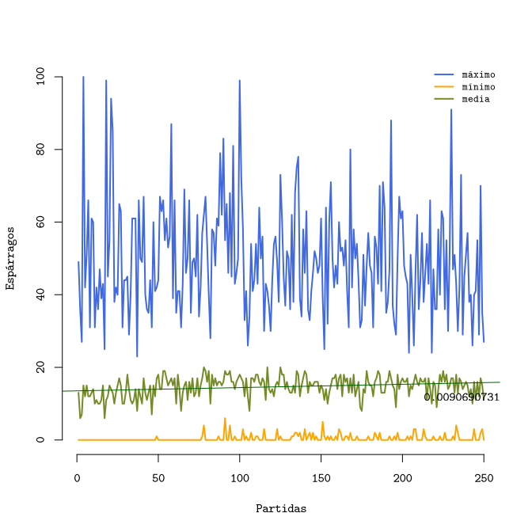

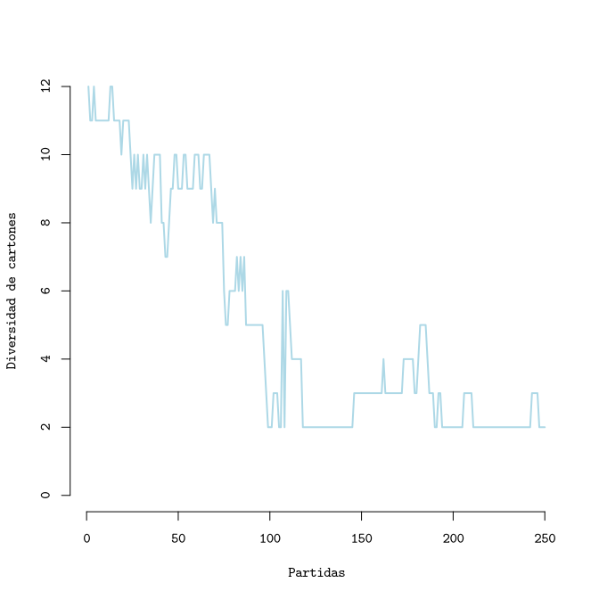

**Figura 17. Al repetir el juego** acabaron de nuevo con las mismas letras ¡pero distintas al juego anterior!

Para animar el cotarro y rizando el rizo de la tranfulla, alguno empezó a cambiar alguna letra de su cartón, de vez en cuando y al tuntún, a ver si podía mejorar su estrategia.

```
'                            # # # # # # # # #
'                            #  Y E M A   5  #   abu05.bas
'                            # # # # # # # # #
'
' REM GIUSSEPPE
randomize timer
' screenres 100, 100, 8

data "Javié", "Manolo", "Antoñito", "Fali", "Juanjosé", "Rafa"
data "Ávila", "Codina", "Paquito", "Garcíaluque", "Durán", "Abundio"
data "Juanín", "Kiko", "Juanma", "Célula", "Mocoso", "Carahuevo"
data "Charlesboyer", "Carlos", "Lepe", "Joselete", "Zambrano", "Galán"
data "González", "Román", "Bellido", "Pérez", "Álvarez", "Martín"
data "Vargas", "Núñez", "Carri", "Cuevas", "Cruzado", "Finley"
data "Escudero", "Matas", "Monti", "Lara", "Iorfida", "Bernabé"


'---- definir variables y tipos

' principales
dim as integer esp, re_min, re_max
dim as integer xmax, ymax
dim as integer pasos
dim as integer veces

'auxiliares
dim as integer i, j, t
dim as integer yi, y_arr, y_abj
dim as integer xi, x_der, x_izq
dim as integer borde
dim as integer vez
dim as integer cara
dim as string mueve
dim as integer n_amigos
dim as integer maximo, amigo_max, minimo, amigo_min, media
dim as string flangolosina, flangolosina_n, pringao, pringao_n
dim as integer pc, fc, amigo_azar
dim as integer diversidad, nuevo
dim as single pizq, pade, pdch

```

[output cut: 217 more lines]

```
    ' print "mínimo: "; minimo; "  "; pringao; "  "; pringao_n
    'sleep

    '---- grabar los datos
    print #1, vez, minimo, pringao, pringao_n, maximo, flangolosina, flangolosina_n, media, diversidad, pizq, pade, pdch

next vez

close #1

print
print "CARTONES FINALES"
for i = 1 to n_amigos
    print carton(i)
next i
```

```r
                              # # # # # # # #
                              #  C L A R A  #   versión 5
                              # # # # # # # #

esp <- 9           # número de esparragueras
re_min <- 1        # radio mínimo de la esparraguera
re_max <- 6        #   "   máximo   "

#---- Espacio
xmax <- 100        # ancho de la pradera (desde x = 1 hasta x = 100)
ymax <- 100        # largo        "

#---- Paseo
pasos <- 1000

#---- Repeticiones
veces <- 250

#---- Amigos
n_amigos <- 12

#---- pasar los coeficientes
f_coef <- "coef_abu05.txt"
write(esp, f_coef)
write(re_min, f_coef, append = TRUE)
write(re_max, f_coef, append = TRUE)
write(xmax, f_coef, append = TRUE)
write(ymax, f_coef, append = TRUE)
write(pasos, f_coef, append = TRUE)
write(veces, f_coef, append = TRUE)
write(n_amigos, f_coef, append = TRUE)

#---- pasar la matriz de esparragueras
write(XYespar_ini, "XYesp_abu00.txt", ncolumns = xmax)


#---- llamar a la nueva yema
system("./abu05")
```

```
esp:  9
re_min:  1
re_max:  6
xmax:  100
ymax:  100
pasos:  1000
veces:  250
número de amigos:  12

CARTONES INICIALES
AAIDIA
DAADIA
DIDIDA
AIIAID
IDIAAD
IADAAD
DIIAAA
DIIADI
DIAIID
IADADA
AIIDAD
IIDDDA

CARTONES FINALES
DAADAA
IAAADA
IAADAA
AAIDAA
IDAAAA
IDADAA
DAADAA
AAADAA
IAIAAA
IAAADD
AAADAA
AAAIAA
```

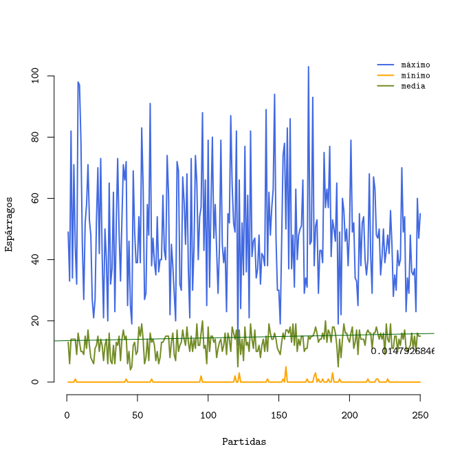

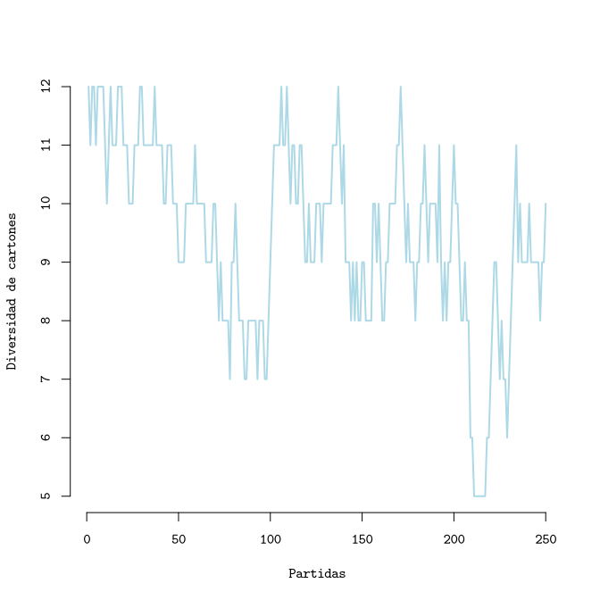

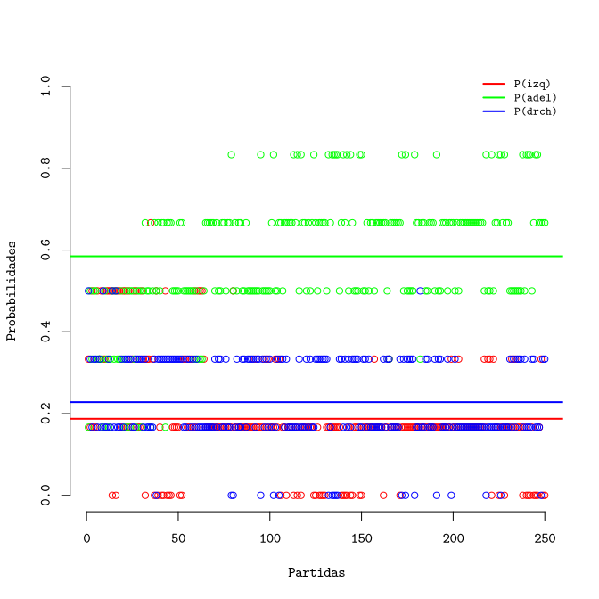

```r
#---- ver los resultados
abu05 <- (read.csv("abu05.txt", sep=""))
{
par(family = "LM Mono 8", bty = "n")
plot(abu05$Max,
    type = "l",
    lwd = 2,
    col = "royalblue",
    ylim = c(0, max(abu05$Max)),
    ylab = "Espárragos",
    xlab = "Partidas")
# text(1:100, abu04$Max, abu04$Flangolosina, cex = 0.8)
lines(abu05$Min,
    lwd = 2,
    col = "orange")
lines(abu05$Media,
    lwd = 2,
    col = c_espar)

ajuste2 <- lm(abu05$Media ~ abu05$Ae)
abline(ajuste1, col = "darkgreen")
text(veces,
    mean(abu05$Media),
    ajuste2$coefficients[2],
    pos = 1)
# text(1:100, abu04$Min, abu04$Pringao, cex = 0.8)
legend("topright",
    c("máximo", "mínimo", "media"),
    lwd = 2,
    col = c("royalblue", "orange", c_espar),
    cex = 0.8,
    bty = "n")

plot(abu05$Diversidad,
    type = "l",
    lwd = 2,
    col = "lightblue",
    ylab = "Diversidad de cartones",
    xlab = "Partidas")

plot(abu05$Pizq,
    col = "red",
    ylab = "Probabilidades",
    ylim = c(0,1),
    xlab = "Partidas")
points(abu05$Pade, col = "green")
points(abu05$Pdch, col = "blue")
legend("topright",
    c("P(izq)", "P(adel)", "P(drch)"),
    lwd = 2,
    col = c("red", "green", "blue"),
    cex = 0.8,
    bty = "n")
abline(h = mean(abu05$Pizq), lwd = 2, col = "red")
abline(h = mean(abu05$Pade), lwd = 2, col = "green")
abline(h = mean(abu05$Pdch), lwd = 2, col = "blue")
}
```

**Figura 18. A pesar de las nuevas trampas** nadie mejoraba en sus puntuaciones. Aunque ahora se mantenía la diversidad de los cartones, la estrategia ganadora siempre consistía en 4 partes adelante, 1 parte a izquierda y otra a derecha, aproximadamente.

Se despertó con una sensación agradable y sin noción del tiempo transcurrido. Hacía mucho que no soñaba con sus amigos de cuando chico. Gracias a su ayuda, Abundio pudo comprobar que la mejor estrategia, si era al azar, consistía en avanzar 4 de cada 6 veces y girar a la izquierda o derecha, indistintamente, las otras 2. Prácticamente, la misma que la segunda que probó antes de llegar el Ozeíllo. Escribió debajo de su dibujo:

$$\operatorname{P}(izquierda) =
\frac{1}{6} \qquad \qquad
\operatorname{P}(adelante) = \frac{4}{6} \qquad \qquad
\operatorname{P}(derecha) = \frac{1}{6}$$

—Si tiro un dado con más caras seguramente podré perfilar mejor la probabilidades —pensó, sin mucha confianza— aunque no creo que cambie cualitativamente el asunto. Tendré que pensar otra cosa.

Miró su sombra y seguía exactamente igual, así que se comió otros cuantos amasquillos y se dio un paseo por la pradera, sin buscar espárragos, solo por el gusto de andar por el campo.

**XVI**